# Course Project

13 November 2016

## Introduction.

This presentation is part of the Peer-graded Assignment: Course Project: Shiny Application and Reproducible Pitch. The goal is to pinch the Web App. It has five slides including the first one and this one. It starts with a summary of the Web App follow by a description of it and, finally, an example of its code.

Web App files can be fund on: https://github.com/victorsalda/Scripts_R

## Summary of the Web App.

This Web App evaluates "The Central Limit Theorem" one of the main concepts in statistics and, thereby, in Data Science.

This theorem states that the distribution of the mean value of a variable obtained from a sample that comes from a population that has any underlying distribution approaches a normal distribution as the sample size increases.

## Description.

The user has to select the number of samples to be chosen from the uniform distribution and the size of them. Then, the Web App shows three figures:

Figure 1. The a histogram with the frequencies of the mean value of the number selected of samples of the specific size.

Figure 2. A normal QQ plot to evaluate (graphically) the normality of the sampling distribution of the sample mean.

Figure 3. The uniform distribution of the population of the values of the variable.

## Example of the code.

Case: 1000 samples of 20 individuals chosen without replacement form a population uniformly distributed.

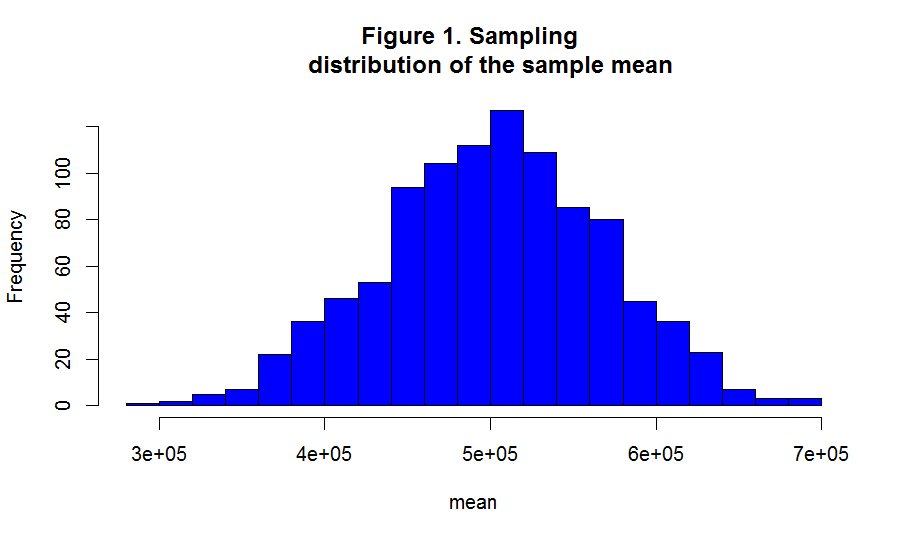

```r
mean<-vector()
       for (i in 1:1000){
         mean[i]<-mean(sample(1:1000000, 20, replace=F))
       }
hist(mean, breaks=15, col="blue",main = "Figure 1. Sampling
     distribution of the sample mean")
```